# islr_ch3_rab

loveroom

2017 11 26

## char 5.3.1

- 검증셋 기법을 사용하는 것을 알아보고 Auto 자료에 다양한 선형모델을 적합한 결과로 인한 검정오차율을 추정한다.

```r
library(ISLR)
set.seed (1)
#392개 관측치중 196개 50%를 선택하여 관측치가 크기가 같은 두부분으로 분할
train=sample(392,196)
#훈련셋 관측치에 선형회귀 적용
lm.fit=lm(mpg~horsepower ,data=Auto,subset=train)
attach(Auto)
#predect함수를 사용하여 392개 관측치 모두에 대한 반응변수값을 추정
#검증셋 내 196개에 관측치의 MSE를 구함
#선형회귀 적합에 대한 추정된 검정   MSE는 26.14이다.
mean((mpg-predict(lm.fit,Auto))[-train]^2)
```

```
## [1] 26.14142
```

```r
#poly 함수를 이용하여 다항식및 삼차회귀에 대한 검정오차를 추정
lm.fit2=lm(mpg~poly(horsepower ,2),data=Auto,subset=train)
mean((mpg-predict(lm.fit2,Auto))[-train]^2)
```

```
## [1] 19.82259
```

```r
lm.fit3=lm(mpg~poly(horsepower ,3),data=Auto,subset=train)
mean((mpg-predict(lm.fit3,Auto))[-train]^2)
```

```
## [1] 19.78252
```

```r
#다른 훈련셋을 선택한 검증셋
# 1차, 2차 ,삼차항을 가진 각모델의 검증셋 오차율을 살펴보며 23.30 18.90 19.26이다.
# housepower 이차 함수를 사용하여 mpg를예측하는 모델이 일차함수만 관련된 모델보다 성능이 더 낫다.
# 모델이 housepower의 삼차함수를 사용해야 할 근거는 거의 없다.
set.seed (2)
train=sample(392,196)
lm.fit=lm(mpg~horsepower ,subset=train)
mean((mpg-predict(lm.fit,Auto))[-train]^2)
```

```
## [1] 23.29559
```

```r
lm.fit2=lm(mpg~poly(horsepower ,2),data=Auto,subset=train)
mean((mpg-predict(lm.fit2,Auto))[-train]^2)
```

```
## [1] 18.90124
```

```r
lm.fit3=lm(mpg~poly(horsepower ,3),data=Auto,subset=train)
mean((mpg-predict(lm.fit3,Auto))[-train]^2)
```

```
## [1] 19.2574
```

### 5.3.2 LOO교차 검증

```r
#loocv 추정치는 임의의 일반화 선형모델에 대해  glm과 cv.glm 함수를 사용하여 자동으로 될 수 있다.
#glm함수는 family="binomial" , 로지스틱 회귀를 수행
#family 인자 없이 모델을 적합하면 glm()은 lm()함수와 같다.

#coef() 함수를 사용하여 모형 인수들의 절편과 기울기 등
glm.fit=glm(mpg~horsepower ,data=Auto)
coef(glm.fit)
```

```
## (Intercept)  horsepower
##  39.9358610  -0.1578447
```

```r
lm.fit=lm(mpg~horsepower ,data=Auto)
coef(lm.fit)
```

```
## (Intercept)  horsepower
##  39.9358610  -0.1578447
```

```r
# 이 Lab에서는 선형회귀를 수행하는데 lm()이 아니라 glm()함수를 사용할 것이다.
# glm () 함수는 cv.glm()과 함께 사용될 수 있기 때문이다.
# cg.glm() 함수는 boot라이브러리에 포함되어 있다.

library(boot)
glm.fit=glm(mpg~horsepower ,data=Auto)
cv.err=cv.glm(Auto,glm.fit)
cv.err$delta
```

```
## [1] 24.23151 24.23114
```

```r
# 복잡한 다항식 적합에 반복
cv.error=rep(0,5)
for (i in 1:5){
glm.fit=glm(mpg~poly(horsepower ,i),data=Auto)
cv.error[i]=cv.glm(Auto,glm.fit)$delta[1]
}
cv.error
```

```
## [1] 24.23151 19.24821 19.33498 19.42443 19.03321
```

### 5.3.3. K-fold 교차 검증

- cv.glm은 k-folder CV를 수행하는데 사용가능하다.
- cv.glm은 5-2 수식을 사용하지 않는다.
- k= 10을 auto 자료에 적용
- k-folder CV 수행시 두값은 조금 다르다.
- 첫번째는 k-folder CV 추정치이고 두번째는 편향이 수정된 값이다.

```r
set.seed(17)
cv.error.10=rep(0,10)
for (i in 1:10){
glm.fit=glm(mpg~poly(horsepower ,i),data=Auto)
cv.error.10[i]=cv.glm(Auto,glm.fit,K=10)$delta[1]
}
cv.error.10
```

```
##  [1] 24.20520 19.18924 19.30662 19.33799 18.87911 19.02103 18.89609
##  [8] 19.71201 18.95140 19.50196
```

## 5.3.4 붓스트랩

### 통계량의 정확도 추정

- 큰장점은 거의 모든 상황에 적용될 수 있다.
- 사용방법은 통계량 함수생성한후 boot()함수 사용
- 투자의 전체 위험또는 분산을 최소화하는 알파함수를 먼저 alpha.fn 생성

```r
alpha.fn=function(data,index){
X=data$X[index]
Y=data$Y[index]
return((var(Y)-cov(X,Y))/(var(X)+var(Y)-2*cov(X,Y)))
}
```

- X와 Y의 두 자산 각각에 대해 100 개의 수익을 포함하는 간단한 시뮬레이션 데이터 세트입니다

```r
library(ISLR)
Portfolio
```

```
##               X           Y
## 1   -0.89525089 -0.23492353
## 2   -1.56245433 -0.88517599
## 3   -0.41708988  0.27188802
## 4    1.04435573 -0.73419750
## 5   -0.31556841  0.84198343
## 6   -1.73712385 -2.03719104
## 7    1.96641316  1.45295666
## 8    2.15286790 -0.43413863
## 9   -0.08120803  1.45080850
## 10  -0.89178179  0.82101623
## 11  -0.29320170 -1.04239112
## 12   0.50577917  0.60847783
## 13   0.52675125 -0.22249334
## 14   1.06646932  1.23135668
```

[output cut: 86 more lines]

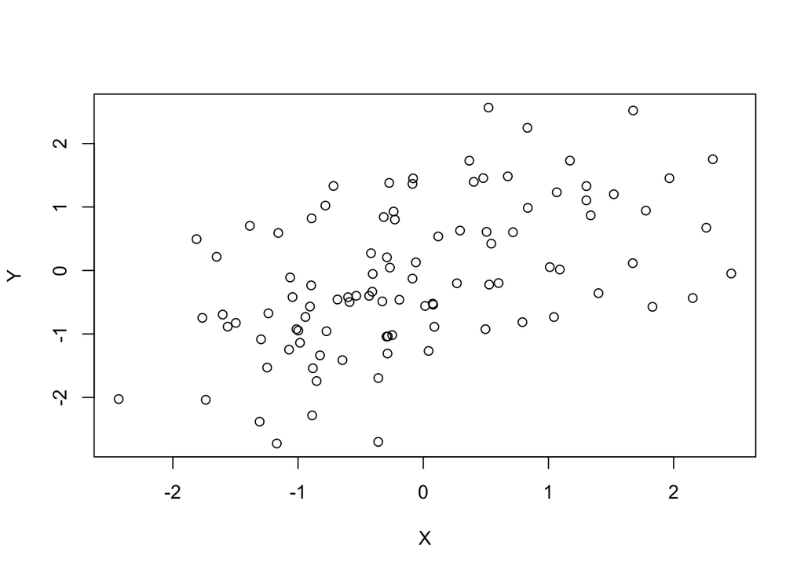

```r
plot(Portfolio)
```

- 5.2의 Portfolio자료 100개 관측치 모두를 사용하여 α를추정한다.

```r
alpha.fn(Portfolio ,1:100)
```

```
## [1] 0.5758321
```

```r
# 100개 관측치를 램더으로  복원추춣한다.
# 모두를 사용하여 α를추정한다.
set.seed (1)
alpha.fn(Portfolio,sample(100,100,replace=T))
```

```
## [1] 0.5963833
```

```r
#boot 함수 : α에 대한 대응하는 모든 추정치를 기록하고 표준편자를 자동으로 해준다.
boot(Portfolio ,alpha.fn,R=1000)
```

```
##
## ORDINARY NONPARAMETRIC BOOTSTRAP
##
##
## Call:
## boot(data = Portfolio, statistic = alpha.fn, R = 1000)
##
##
## Bootstrap Statistics :
##      original        bias    std. error
## t1* 0.5758321 -7.315422e-05  0.08861826
```

### 선형회귀모델의 정확도 추정

- boot.fn 함수는 관측치들을 램덤으로 복원 추출하여 절편과 기울기에 대한 붓스트랩 추정치를 생성하는 데 사용
- Auto자료의 절편과 기울기에 대한 추정치의 변동성을 평가에 사용

```r
boot.fn=function(data,index)
  return(coef(lm(mpg~horsepower ,data=data,subset=index)))

boot.fn(Auto ,1:392)
```

```
## (Intercept)  horsepower
##  39.9358610  -0.1578447
```

```r
set.seed (1)
boot.fn(Auto,sample(392,392,replace=T))
```

```
## (Intercept)  horsepower
##  38.7387134  -0.1481952
```

```r
boot.fn(Auto,sample(392,392,replace=T))
```

```
## (Intercept)  horsepower
##  40.0383086  -0.1596104
```

```r
 boot(Auto ,boot.fn ,1000)
```

```
##
## ORDINARY NONPARAMETRIC BOOTSTRAP
##
##
## Call:
## boot(data = Auto, statistic = boot.fn, R = 1000)
##
##
## Bootstrap Statistics :
##       original      bias    std. error
## t1* 39.9358610  0.02972191 0.860007896
## t2* -0.1578447 -0.00030823 0.007404467
```

```r
 boot(Auto ,boot.fn ,1000)
```

```
##
## ORDINARY NONPARAMETRIC BOOTSTRAP
##
##
## Call:
## boot(data = Auto, statistic = boot.fn, R = 1000)
##
##
## Bootstrap Statistics :
##       original        bias    std. error
## t1* 39.9358610 -0.0030460866 0.887376595
## t2* -0.1578447 -0.0001363144 0.007702537
```

- 표준 공식을 이용하여 선형회귀 모델의 회귀계수에 대한 표준오차 계산

```r
summary(lm(mpg~horsepower ,data=Auto))$coef
```

```
##               Estimate  Std. Error   t value      Pr(>|t|)
## (Intercept) 39.9358610 0.717498656  55.65984 1.220362e-187
## horsepower  -0.1578447 0.006445501 -24.48914  7.031989e-81
```

```r
boot.fn=function(data,index)
  coefficients(lm(mpg~horsepower+I(horsepower^2),data=data,subset=index))
set.seed (1)
boot(Auto ,boot.fn ,1000)
```

```
##
## ORDINARY NONPARAMETRIC BOOTSTRAP
##
##
## Call:
## boot(data = Auto, statistic = boot.fn, R = 1000)
##
##
## Bootstrap Statistics :
##         original        bias     std. error
## t1* 56.900099702  6.098115e-03 2.0944855842
## t2* -0.466189630 -1.777108e-04 0.0334123802
## t3*  0.001230536  1.324315e-06 0.0001208339
```